# Regression Discontinuity Design (RDD)

This project replicates the study by Carpenter & Dobkin (2009), which investigates the causal effect of legal access to alcohol at age 21 on mortality among young adults in the United States. The key idea is that when people legally gain access to alcohol at age 21, risky behaviors like drunk driving and alcohol-related accidents may increase and this should show up as a sudden jump in death rates right at that age.

The Regression Discontinuity Design (RDD) is used as a causal inference method to exploits a sharp cutoff (in this case, the 21st birthday) to identify the treatment effect.

The idea behind RDD is that individuals just below and just above age 21 are very similar in every respect except for legal access to alcohol. Therefore, any sudden jump in mortality at age 21 can be interpreted as the causal effect of alcohol access.

The local polynomial regressions is applied within different bandwidths (±0.5, ±1, ±1.5, ±2 years around the threshold) and estimates whether there is a discontinuous change in mortality at the threshold. Both flexible models (allowing age slopes to differ on each side) and more constrained models (same slopes on both sides, only a jump at 21) are tested to check robustness.

```r
library(tidyverse)
library(dplyr)
library(fixest)      # for feols()
library(broom)       # for tidy()
```

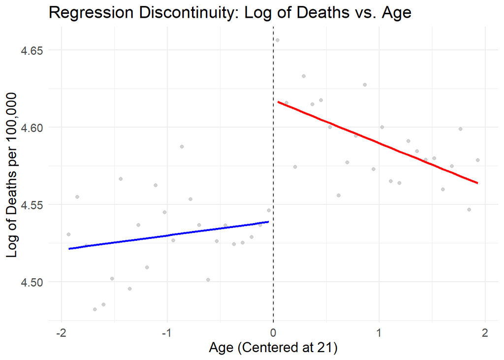

```r
alcohol_data = read.csv("carpenter_dobkin_2009.csv")

# Centering the forcing variable (agecell) around the threshold (21 years)
threshold = 21
alcohol_data = alcohol_data %>%
  mutate(age_centered = agecell - threshold) %>%
  filter(!is.na(all_deaths)) %>% # Removing missing values
  mutate(log_all_deaths = log(all_deaths)) # Calculating the log outcome variable

# Spliting the data into pre- and post-threshold groups
pre_threshold = alcohol_data %>% filter(age_centered < 0)
post_threshold = alcohol_data %>% filter(age_centered >= 0)

# Fitting separate regression models for pre- and post-threshold groups
pre_model = lm(log_all_deaths ~ age_centered, data = pre_threshold)
post_model = lm(log_all_deaths ~ age_centered, data = post_threshold)

# regression predictions
pre_threshold = pre_threshold %>%
  mutate(predicted = predict(pre_model, newdata = pre_threshold))
post_threshold = post_threshold %>%
  mutate(predicted = predict(post_model, newdata = post_threshold))

# Combining pre- and post-threshold predictions for plotting
predictions = bind_rows(pre_threshold, post_threshold)


ggplot(alcohol_data, aes(x = age_centered, y = log_all_deaths)) +
  geom_point(alpha = 0.7, color = "gray") +
  geom_line(data = predictions %>% filter(age_centered < 0), aes(y = predicted), color = "blue", size = 1) +
  geom_line(data = predictions %>% filter(age_centered >= 0), aes(y = predicted), color = "red", size = 1) +
  geom_vline(xintercept = 0, linetype = "dashed", color = "black") +
  labs(
    title = "Regression Discontinuity: Log of Deaths vs. Age",
    x = "Age (Centered at 21)",
    y = "Log of Deaths per 100,000"
  ) +
  theme_minimal() +
  theme(text = element_text(size = 14))
```

```r
threshold = 21
alcohol_data = alcohol_data %>%
  mutate(age_centered = agecell - threshold) %>%
  filter(!is.na(all_deaths)) %>%
  mutate(
    log_all_deaths = log(all_deaths),
    treated = ifelse(age_centered >= 0, 1, 0)
  )

#window sizes
window_sizes = c(0.5, 1, 1.5, 2)

## Initializing a results dataframe
results = tibble()

#Looping over window sizes
for (window in window_sizes) {

  #Subseting the data within the window
  subset_data = alcohol_data %>%
    filter(abs(age_centered) <= window)

  # local linear regression with a quadratic term using fixest::feols()
  model = feols(
    log_all_deaths ~ age_centered * treated + I(age_centered^2) * treated,
    data = subset_data,
    vcov = "hetero"
  )

  # Extracting the results for the discontinuity term
  tidy_model = broom::tidy(model) %>%
    filter(term == "treated") %>%
    mutate(
      window_size = window,
      lower = estimate - 1.96 * std.error,
      upper = estimate + 1.96 * std.error
    ) %>%
    select(window_size, late = estimate, se = std.error, lower, upper, p.value)

  # Appending results
  results = bind_rows(results, tidy_model)
}


print(results)
```

```
## # A tibble: 4 × 6
##   window_size   late     se  lower upper    p.value
##         <dbl>  <dbl>  <dbl>  <dbl> <dbl>      <dbl>
## 1         0.5 0.109  0.0239 0.0622 0.156 0.00382
## 2         1   0.0968 0.0229 0.0520 0.142 0.000496
## 3         1.5 0.104  0.0222 0.0609 0.148 0.0000537
## 4         2   0.0972 0.0184 0.0612 0.133 0.00000415
```

```r
threshold = 21
alcohol_data = alcohol_data %>%
  mutate(age_centered = agecell - threshold) %>%
  filter(!is.na(all_deaths)) %>%
  mutate(
    log_all_deaths = log(all_deaths),
    above_threshold = ifelse(age_centered >= 0, 1, 0)
  )

# window sizes
window_sizes = c(0.5, 1, 1.5, 2)

# Initializing a results dataframe
results = tibble()

# Looping over window sizes
for (window in window_sizes) {

  # Subseting the data within the window
  subset_data = alcohol_data %>%
    filter(abs(age_centered) <= window)

  # local linear regression with a quadratic term using fixest::feols()
  model = feols(
    log_all_deaths ~ age_centered + I(age_centered^2) + above_threshold,
    data = subset_data,
    vcov = "hetero"
  )

  # Extracting the results for the discontinuity term
  tidy_model = tidy(model) %>%
    filter(term == "above_threshold") %>%
    mutate(
      window_size = window,
      lower = estimate - 1.96 * std.error,
      upper = estimate + 1.96 * std.error
    ) %>%
    select(window_size, late = estimate, se = std.error, lower, upper, p.value)

  # Appending results
  results = bind_rows(results, tidy_model)
}


print(results)
```

```
## # A tibble: 4 × 6
##   window_size   late     se  lower upper     p.value
##         <dbl>  <dbl>  <dbl>  <dbl> <dbl>       <dbl>
## 1         0.5 0.0899 0.0295 0.0321 0.148 0.0159
## 2         1   0.0998 0.0203 0.0600 0.140 0.0000828
## 3         1.5 0.0891 0.0154 0.0589 0.119 0.00000206
## 4         2   0.0784 0.0136 0.0518 0.105 0.000000749
```

The estimates of the Local Average Treatment Effect (LATE) range from 0.078 to 0.099, depending on the window size.if the LATE values changed significantly with larger windows, it could suggest that the results are influenced by observations further from the threshold. Stability across window sizes confirms that the effect is not sensitive to the choice of window size, indicating robustness. for example LATE values remain in a narrow range (close to 0.096), standard errors decrease and confidence intervals tighten with larger windows and P-values remain consistently small, showing statistical significance.

The key trade-off in a Regression Discontinuity (RD) analysis lies in the choice of window size around the threshold:

Narrow Windows: Focuses on observations very close to the threshold (age 21), where the treatment and control groups are most comparable.it Reduces the likelihood of bias from unrelated trends in the running , but it Uses fewer observations, leading to higher standard errors (less precise estimates) and so results are more sensitive to noise or random variation in the data.

Wider windows: Includes more observations, leading to smaller standard errors (more precise estimates) by captures a broader perspective on the relationship between age and mortality, which may reflect more generalization patterns, but it may include observations further from the threshold, where the treatment and control groups are less comparable and so increases the risk of bias from unrelated trends in the running variable (like age-related changes in mortality).

The first LATE estimates are a little bit higher for most window sizes in comparison to the second ones (except for the ±1 window).this could be because of the full interaction terms used in the new model, which account for both linear and quadratic trends.

The first version SEs are slightly larger than the second ones, especially for wider windows. This shows slightly less precision in the new model.

The second version P-values are significantly smaller than the first ones, which may suggest the old model produced more statistically significant results due to its smaller SEs.

Generally, theoretically the first version could be more robust by interacting both the linear and quadratic terms with the treatment variable. because the LATE estimates align more closely with the reported values in the paper (around 0.096). Although the SEs and p-values are slightly less favorable, the first model’s estimates remain highly statistically significant and more comprehensive.